# Analysis of the trajectories of the harvesters using HMM

In this document I will present some results and interpretations of the analysis of the spatial trajectories of the harvesters using Hidden Markov Models (HMM).

## 0. Introduction to HMM

Hidden Markov models (HMMs) are models in which the distribution that generates an observation $Z_t$ depends on the state $S_t$ of an underlying and unobserved Markov process (that satisfies the Markov property; Figure 1). In the context of animal movement, the state $S_t$ is interpreted as a proxy for the behavioral state of the animal (e.g. foraging, exploring). The observations $Zt$ are bivariate time series ($Zt = (l_t, \phi_t)$) where $l_t$ is the step length (the Euclidean distance) and $\phi_t$ the turning angle, between two succesive locations Zucchini (2016). Biologically speaking, these models try to include the process where the movement of agents (e.g. short or large steps) depends on its behavior. With these models, we can define the most likely sequence of states along the trajectory of an agent, its average time within a state, and the number of switches between states.

[figure not shown]

Representation of the HMM. taken from (Michelot, Langrock and Patterson, 2019)

## 1. Fitting of HMM

### 1.1. Preparation of data

We loaded *ggplot2*, *dplyr*, *tidyverse* and *movehmm* libraries. We then loaded the data of the trajectories and did some punctual modifications to it. We had in total 12 trajectories, with ($x, y$) coordinates (Fig. 2).

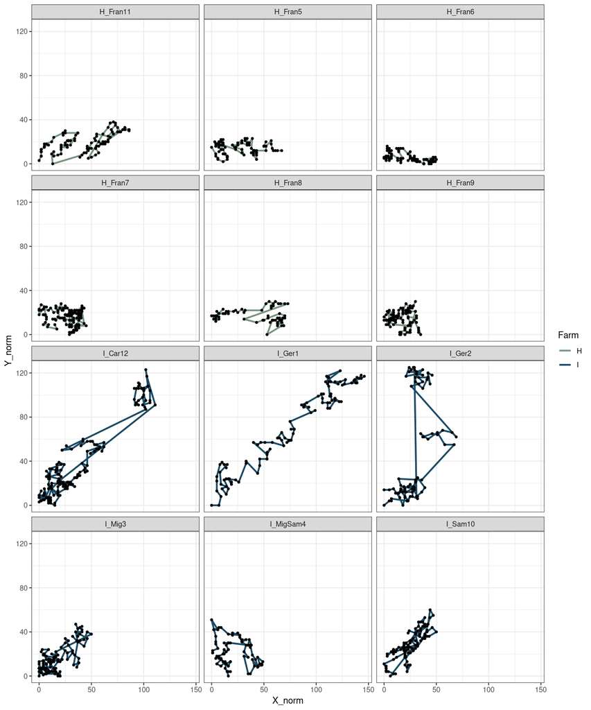

```
Movement data for 12 tracks:
I_Ger1 -- 100 observations
I_Ger2 -- 80 observations
I_Mig3 -- 107 observations
I_MigSam4 -- 76 observations
H_Fran5 -- 77 observations
H_Fran6 -- 70 observations
H_Fran7 -- 115 observations
H_Fran8 -- 63 observations
H_Fran9 -- 97 observations
I_Sam10 -- 104 observations
H_Fran11 -- 88 observations
I_Car12 -- 158 observations
No covariates.
```

A first assumption for the analysis was made: we took these time irregular trajectories (where each point represents one different tree, but where the time between two trees is variable) and treated them as a regular trajectories. This aimed to analyze the change in the movement of the workers during a day, generated by the underlying pattern of trees or by the differences in the fruit charge and ripening synchronicity. We convert this database into a movehmm object where the step distance $l_t$ and the relative angle $\phi_t$ between the $(x, y)$ coordinates is calculated (table 1). We plotted the histograms of both the steps and the angles (Fig. 3 and Fig. 4).

First lines of the movehmm object

| ID | step | angle | x | y |
| --- | --- | --- | --- | --- |
| I_Ger1 | 3.605551 | NA | 146 | 117 |
| I_Ger1 | 3.000000 | -2.158799 | 143 | 115 |
| I_Ger1 | 3.605551 | 2.553590 | 143 | 118 |
| I_Ger1 | 2.236068 | -1.446441 | 141 | 115 |
| I_Ger1 | 5.000000 | 2.034444 | 139 | 116 |
| I_Ger1 | 3.605551 | -2.158799 | 139 | 111 |

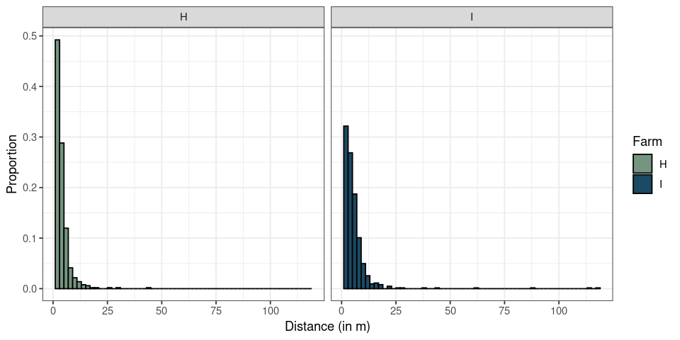

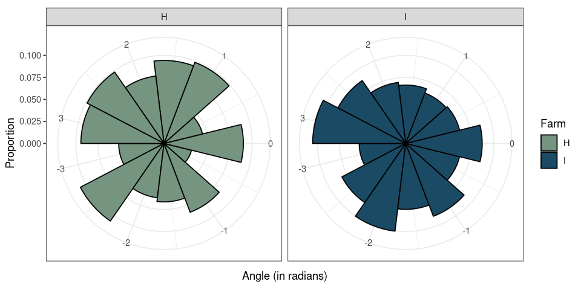

Now, for the following analysis, we only took the step distance and treated both farms as one. We decided to exclude the angles because they didn’t have a biological meaning for irregular trajectories. The input for the analysis is then the histogram presented in Fig. 5.

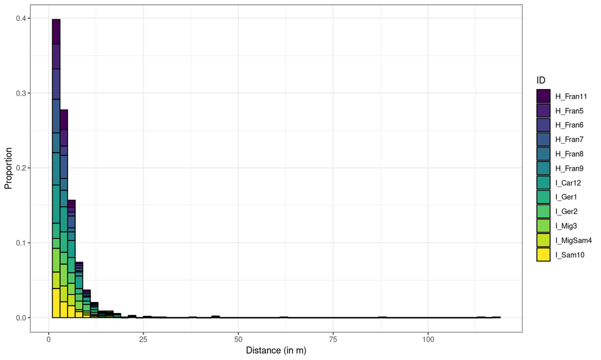

### 1.2. Fitting of the data

The algorithm of the *movehmm* library uses:

1. a predefined number of states. Here we will use two.
2. a defined family of distributions. Here we will try to fit two different exponential families (*gamma* and *weibull*).
3. prior parameters for each of the distributions, for each state.
4. The observations (step-lengths) (the data of harvesters)

With these inputs, the algorithm extracts the most likely two-state-distributions with their respective parameters (within the predefined family of distributions) that fit the data and the most likely sequence of states (assuming a markov process). During the fitting process, the algorithm uses the maximum-log likelihood and the *forward algorithm* (a recursive algorithm starting with the prior distributions; (Zucchini 2016)).

We ran a loop to fit the two different families (*weibull*, and *gamma*) and in order to avoid local maximal likelihoods, we swapped 1000 combinations across a range of prior parameters for each model (Michelot, Langrock, and Patterson 2019). For the *gamma* distribution, the minimum and maximum values of each range were chosen to encompass the full distribution. For the *weibull* distribution, the maximum shape considered the left-skew shape and the scale was chosen to include the 120m long steps (see ranges in table 2). It is important to note that these are only priors guesses, and the real parameters can outbound these limits. Many of these combinations of prior parameters converged to the same final distributions.

Minimun and maximum values of the parameters of the distribution

| value | gamma.mean | gamma.sd | weibull.shape | weibull.scale |
| --- | --- | --- | --- | --- |
| min | 0.1 | 0.1 | 0.0 | 0.1 |
| max | 20.0 | 20.0 | 2.7 | 15.0 |

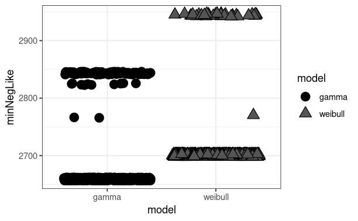

## 2. Results: Description of the states, for each studied distribution.

We plotted the two state distributions for *gamma* and for *weibull* families (Fig. 7). For both families of distribution, one of the states produces a distribution that encompass all highly frequent short steps and falls abruptly size steps around 13 m. The other state generates long tailed distribution with a lower probability and short steps (compared to the other distribution) and a non zero probability for steps bigger than 13 m (Fig. 7)

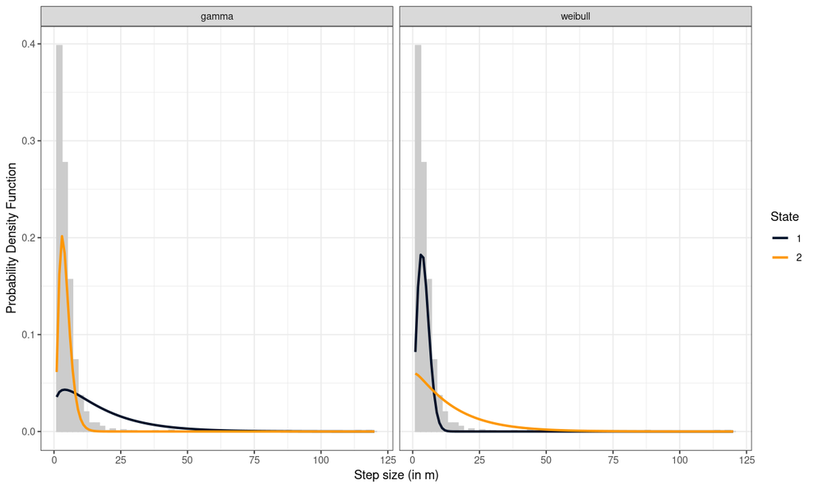

```
Decoding states sequence... DONE
Computing states probabilities... DONE
```

[output not shown]

```
Decoding states sequence... DONE
```

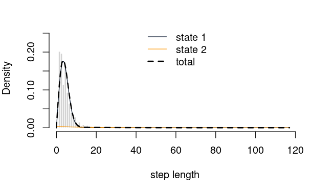

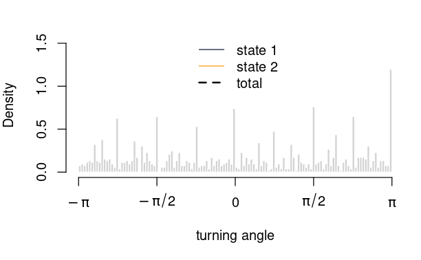

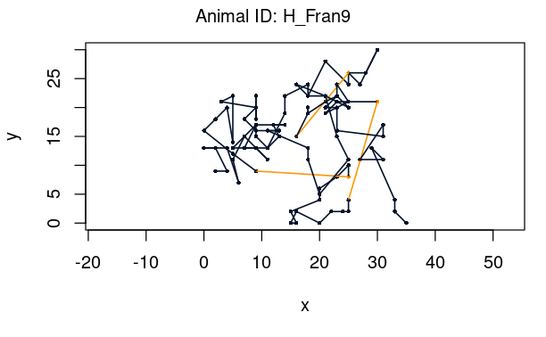

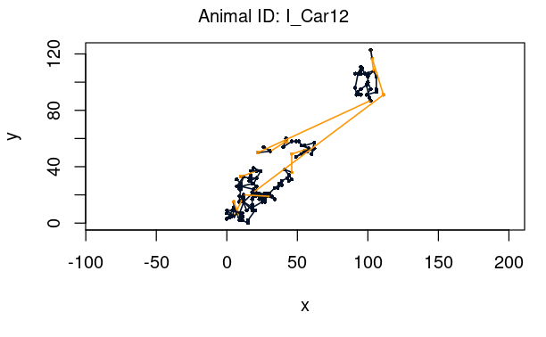

https://cran.r-project.org/web/packages/moveHMM/vignettes/moveHMM-guide.pdf

https://theomichelot.github.io/software/

Michelot, Théo, Roland Langrock, and Toby Patterson. 2019. “moveHMM: An r Package for the Analysis of Animal Movement Data.” *ArXiv Preprint*, 1–24.

Zucchini, MacDonald, W. 2016. *Hidden Markov Models for Time Series: An Introduction Using r*. Chapman; Hall/CRC Press.